# Di-Haem Cytochrome C Peroxidase

Fold-switch pair **2c1vB_2c1uC** — **2c1vB** vs **2c1uC**

Paracoccus pantotrophus

## Figure 1: Phylogenetic tree with per-cluster fold-preference heatmap.

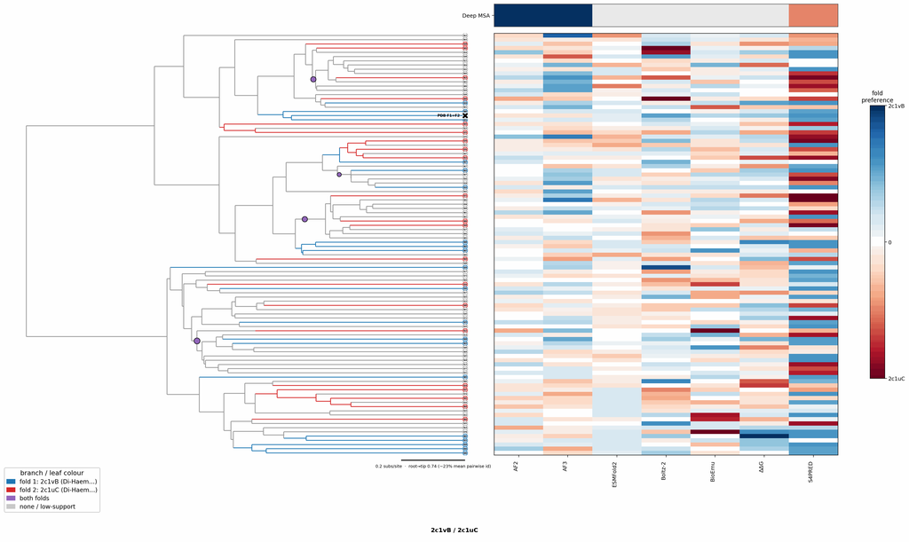

The single fold-switching chain of each fold superposed by TM-align; waters hidden, any ligand shown as green sticks. Grey = structurally conserved core, colour = divergent (fold-switching) region. This pair switches fold coupled to oligomerisation; a single protomer is shown, not the full assembly.

2c1vB (Di-Haem Cytochrome C Peroxidase) · dimer2c1uC (Di-Haem Cytochrome C Peroxidase) · tetramerLigand HEC (bound to 2c1vB), Ligand HEC (bound to 2c1uC)

TM-score: 0.872 · Trigger class: oligomerization

Aligned overlay

Each fold is coloured by per-residue Cα deviation between the two superposed structures: grey ≈ conserved core, full colour = structurally divergent (fold-switching) region.

2c1vB (Di-Haem Cytochrome C Peroxidase)

2c1uC (Di-Haem Cytochrome C Peroxidase)

0 Å5≥10 Å

2c1vB (Di-Haem Cytochrome C Peroxidase)

2c1uC (Di-Haem Cytochrome C Peroxidase)

## Figure 4: Best-cluster predicted contact maps over the two true folds.

Predicted contact maps (MSA-Transformer) for the clusters best matching each fold, over the true contacts of fold 1 (upper triangle) and fold 2 (lower). Divergent contacts between clusters are the contact-level signature of fold-switching.

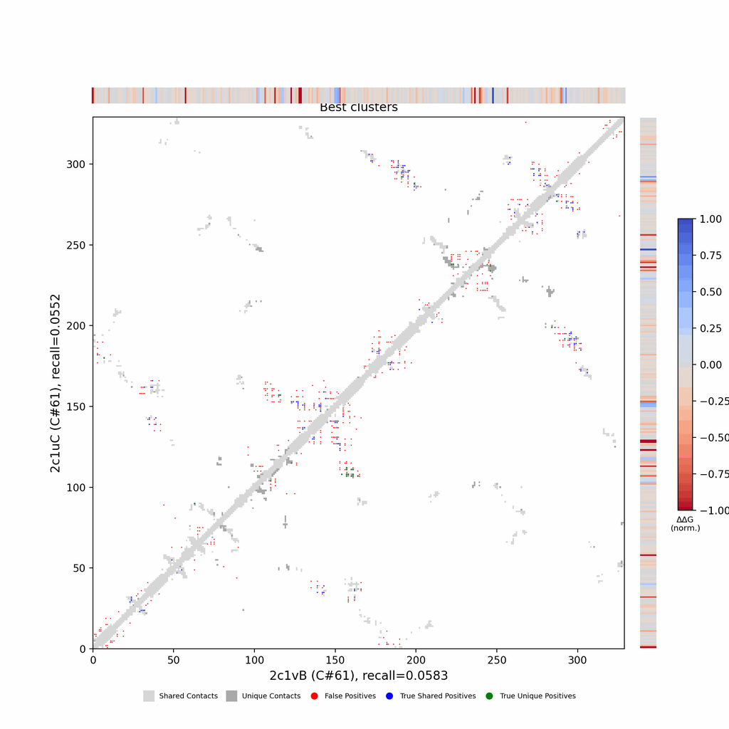

## Figure 5: Per-residue ΔΔG fold-preference contribution

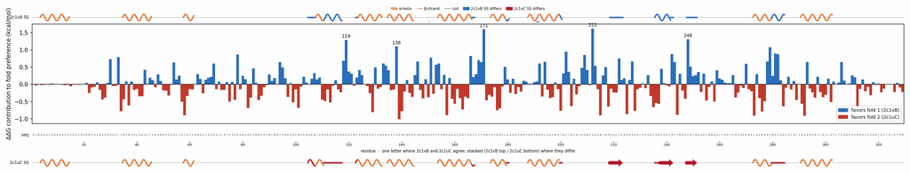

**More figures**

## Figure 6: Deep-MSA contact map panel / Best clusters contact map panel

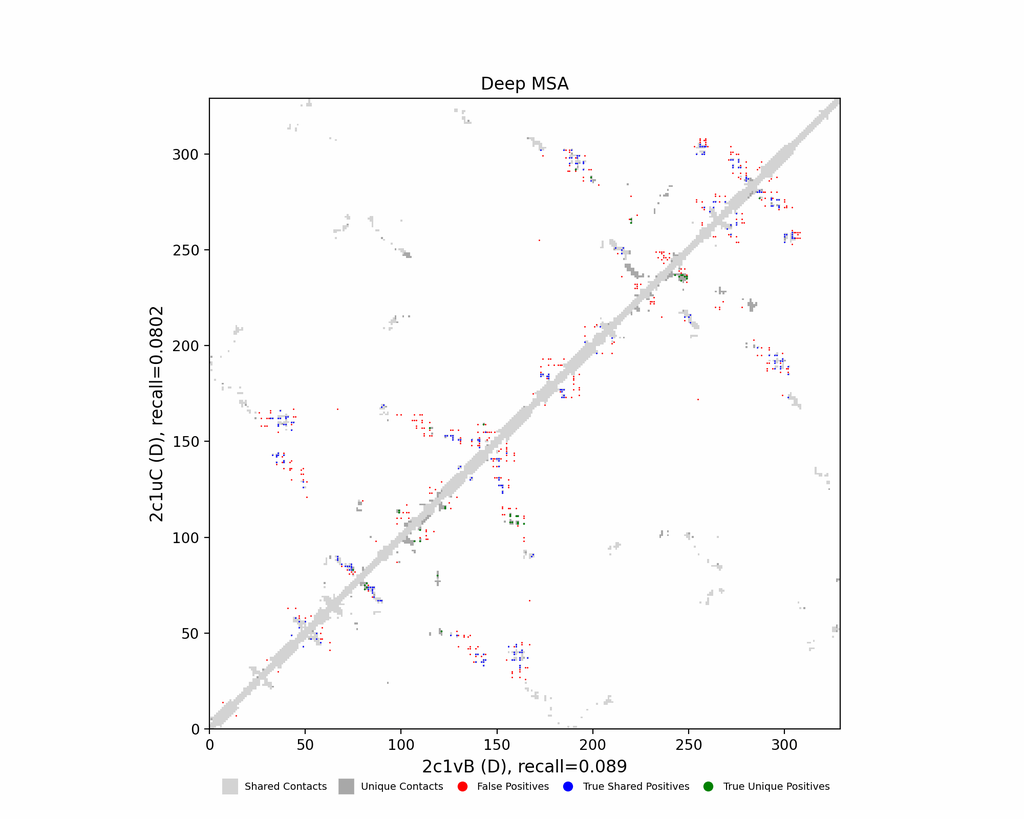

Deep-MSA contact map panel

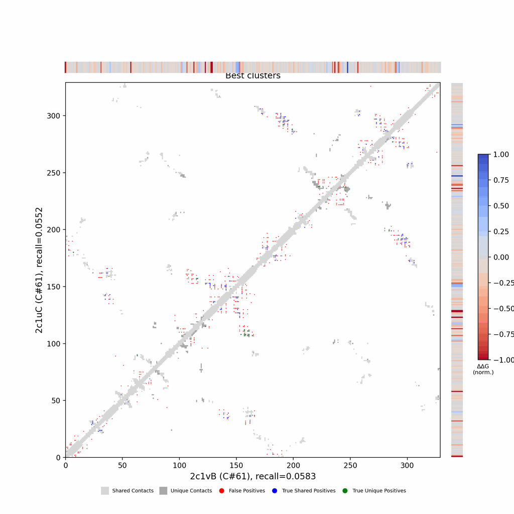

Best clusters contact map panel

## Figure 7: All clusters contact-map mosaic (small multiples).

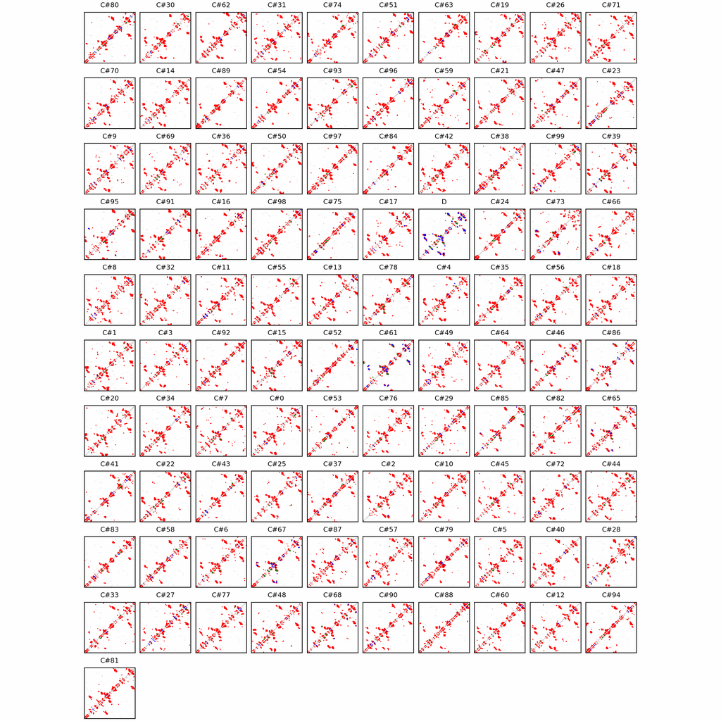

## Figure 8: Phylo null: tree with shuffled cluster fold labels.

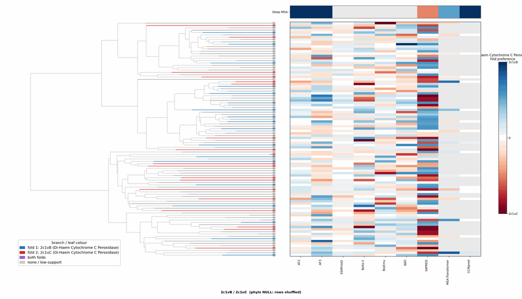

## Cluster metrics table

Per-cluster metrics underlying the figures above.

| cluster | n | neff | AF2_TM1 | AF2_TM2 | AF3_TM1 | AF3_TM2 | RE-MSAT-COM | RE-MSAT1 | RE-MSAT2 | ESM_SEQIDS | ESM_TM1 | ESM_TM2 | ΔΔG_Bias | ΔΔG_Bias_std | ΔΔG_frac_F1 | Boltz2_pref | S4PRED_pref | CCMpred_pref | BioEmu_pref |
| --- | --- | --- | --- | --- | --- | --- | --- | --- | --- | --- | --- | --- | --- | --- | --- | --- | --- | --- | --- |
| Deep | - | - | 0.99 | 0.87 | 0.99 | 0.87 | 0.3 | 0.3 | 0.27 | - | - | - | - | - | - | - | -0.02 | 0.03 | - |
| 000 | 2097.0 | 1158.0 | 0.34 | 0.32 | 0.76 | 0.68 | 0.01 | 0.01 | 0.01 | 001; 001; 002; 002; 008; 008; 009; 009; 005; 005 | 0.85 ± 0.06 | 0.77 ± 0.05 | -1.39 | 6.75 | 0.5 | 0.0 | -0.01 | 0.0 | -0.0 |
| 001 | 1471.0 | 1034.0 | 0.33 | 0.32 | 0.77 | 0.69 | 0.02 | 0.04 | 0.02 | 001; 004; 004; 001; 003; 003; 008; 008; 002; 002 | 0.84 ± 0.01 | 0.76 ± 0.01 | -3.25 | 4.16 | 0.2 | 0.02 | 0.0 | 0.0 | -0.02 |
| 002 | 1304.0 | 918.0 | 0.38 | 0.39 | 0.78 | 0.7 | 0.01 | 0.01 | 0.01 | 001; 001; 004; 004; 002; 005; 002; 005; 008; 008 | 0.87 ± 0.03 | 0.78 ± 0.02 | -1.15 | 5.34 | 0.5 | 0.01 | -0.01 | 0.0 | -0.01 |
| 003 | 1082.0 | 686.0 | 0.33 | 0.34 | 0.4 | 0.39 | 0.01 | 0.02 | 0.01 | 002; 002; 007; 007; 001; 001; 008; 008; 003; 003 | 0.78 ± 0.05 | 0.70 ± 0.05 | -2.07 | 6.61 | 0.4 | 0.01 | -0.0 | 0.0 | 0.0 |
| 004 | 733.0 | 483.0 | 0.42 | 0.42 | 0.95 | 0.87 | 0.01 | 0.01 | 0.01 | 002; 002; 009; 009; 001; 003; 001; 003; 010; 005 | 0.81 ± 0.02 | 0.73 ± 0.02 | -5.89 | 7.3 | 0.1 | -0.0 | 0.01 | -0.0 | 0.02 |
| 005 | 650.0 | 428.0 | 0.39 | 0.41 | 0.56 | 0.56 | 0.0 | 0.0 | 0.01 | 008; 008; 004; 004; 001; 001; 003; 003; 009; 009 | 0.82 ± 0.02 | 0.74 ± 0.03 | -3.49 | 4.47 | 0.2 | 0.01 | -0.02 | -0.0 | 0.0 |
| 006 | 637.0 | 176.0 | 0.34 | 0.33 | 0.45 | 0.42 | 0.01 | 0.02 | 0.01 | 001; 001; 002; 002; 005; 005; 004; 004; 003; 003 | 0.86 ± 0.04 | 0.77 ± 0.04 | -0.2 | 4.41 | 0.5 | -0.02 | 0.01 | -0.0 | 0.0 |
| 007 | 608.0 | 284.0 | 0.32 | 0.32 | 0.82 | 0.75 | 0.01 | 0.02 | 0.01 | 006; 006; 002; 005; 005; 002; 009; 009; 001; 001 | 0.81 ± 0.01 | 0.73 ± 0.02 | 1.33 | 7.27 | 0.7 | -0.01 | -0.01 | -0.0 | 0.01 |
| 008 | 604.0 | 417.0 | 0.41 | 0.41 | 0.76 | 0.68 | 0.01 | 0.01 | 0.01 | 002; 002; 010; 010; 001; 001; 005; 005; 004; 004 | 0.85 ± 0.04 | 0.77 ± 0.03 | 3.17 | 4.51 | 0.8 | 0.02 | 0.03 | 0.0 | 0.0 |
| 009 | 596.0 | 414.0 | 0.22 | 0.26 | 0.32 | 0.33 | 0.03 | 0.03 | 0.02 | 001; 001; 004; 004; 005; 005; 009; 009; 002; 002 | 0.84 ± 0.08 | 0.77 ± 0.06 | -2.56 | 5.44 | 0.3 | -0.05 | -0.01 | 0.0 | -0.0 |
| 010 | 563.0 | 240.0 | 0.25 | 0.22 | 0.72 | 0.7 | 0.0 | 0.01 | 0.0 | 009; 009; 002; 005; 005; 002; 006; 006; 001; 001 | 0.78 ± 0.01 | 0.69 ± 0.02 | 1.03 | 5.02 | 0.8 | 0.01 | 0.03 | -0.0 | 0.01 |
| 011 | 549.0 | 294.0 | 0.3 | 0.3 | 0.42 | 0.43 | 0.03 | 0.02 | 0.02 | 001; 006; 006; 001; 009; 009; 008; 008; 007; 007 | 0.82 ± 0.01 | 0.74 ± 0.01 | 0.41 | 6.5 | 0.5 | -0.01 | 0.01 | 0.0 | -0.0 |
| 012 | 534.0 | 364.0 | 0.43 | 0.47 | 0.79 | 0.71 | 0.0 | 0.0 | 0.0 | 007; 007; 005; 005; 002; 002; 001; 004; 001; 004 | 0.82 ± 0.01 | 0.74 ± 0.02 | -0.72 | 6.58 | 0.5 | 0.0 | -0.0 | -0.0 | -0.03 |
| 013 | 525.0 | 328.0 | 0.35 | 0.32 | 0.66 | 0.66 | 0.03 | 0.03 | 0.02 | 008; 008; 004; 004; 001; 009; 009; 001; 003; 003 | 0.82 ± 0.01 | 0.75 ± 0.02 | -1.29 | 4.48 | 0.3 | 0.01 | -0.02 | -0.0 | 0.0 |
| 014 | 522.0 | 347.0 | 0.33 | 0.31 | 0.43 | 0.42 | 0.0 | 0.02 | 0.01 | 002; 002; 001; 009; 009; 001; 003; 003; 008; 010 | 0.81 ± 0.02 | 0.74 ± 0.01 | -3.94 | 4.78 | 0.2 | 0.01 | -0.02 | -0.0 | 0.01 |
| 015 | 439.0 | 296.0 | 0.4 | 0.4 | 0.47 | 0.46 | 0.01 | 0.03 | 0.02 | 001; 001; 003; 003; 007; 008; 008; 007; 006; 006 | 0.79 ± 0.01 | 0.72 ± 0.00 | -1.3 | 7.62 | 0.5 | 0.0 | 0.01 | 0.0 | 0.0 |
| 016 | 437.0 | 55.0 | 0.44 | 0.45 | 0.74 | 0.74 | 0.01 | 0.01 | 0.01 | 001; 003; 001; 003; 002; 002; 007; 007; 008; 008 | 0.81 ± 0.03 | 0.73 ± 0.02 | -2.21 | 8.14 | 0.5 | -0.01 | 0.03 | -0.0 | -0.01 |
| 017 | 421.0 | 283.0 | 0.28 | 0.26 | 0.39 | 0.38 | 0.02 | 0.01 | 0.02 | 002; 002; 007; 007; 001; 001; 005; 005; 008; 008 | 0.82 ± 0.03 | 0.74 ± 0.02 | -2.65 | 3.43 | 0.2 | -0.02 | 0.03 | 0.0 | -0.0 |
| 018 | 415.0 | 291.0 | 0.33 | 0.34 | 0.77 | 0.69 | 0.01 | 0.01 | 0.01 | - | - | - | -0.97 | 6.73 | 0.4 | -0.0 | -0.0 | - | 0.01 |
| 019 | 394.0 | 207.0 | 0.5 | 0.51 | 0.76 | 0.7 | 0.02 | 0.02 | 0.02 | - | - | - | 3.6 | 3.66 | 0.9 | -0.0 | 0.03 | - | 0.01 |
| 020 | 365.0 | 252.0 | 0.36 | 0.36 | 0.55 | 0.52 | 0.0 | 0.02 | 0.0 | - | - | - | -2.64 | 5.15 | 0.2 | -0.01 | 0.03 | - | 0.01 |
| 021 | 365.0 | 94.0 | 0.38 | 0.38 | 0.56 | 0.52 | 0.01 | 0.01 | 0.01 | - | - | - | 2.31 | 5.06 | 0.6 | -0.0 | 0.01 | - | 0.01 |
| 022 | 358.0 | 179.0 | 0.36 | 0.36 | 0.69 | 0.65 | 0.01 | 0.03 | 0.01 | - | - | - | -1.8 | 4.89 | 0.4 | 0.02 | 0.03 | - | 0.0 |
| 023 | 342.0 | 244.0 | 0.42 | 0.41 | 0.53 | 0.53 | 0.01 | 0.03 | 0.01 | - | - | - | -1.31 | 5.55 | 0.5 | -0.0 | 0.02 | - | 0.01 |
| 024 | 338.0 | 82.0 | 0.37 | 0.38 | 0.34 | 0.35 | 0.02 | 0.02 | 0.02 | - | - | - | -7.14 | 6.95 | 0.1 | 0.0 | 0.0 | - | -0.0 |
| 025 | 328.0 | 226.0 | 0.3 | 0.28 | 0.62 | 0.57 | 0.0 | 0.01 | 0.0 | - | - | - | -1.37 | 3.34 | 0.2 | 0.0 | 0.03 | - | -0.0 |
| 026 | 326.0 | 196.0 | 0.5 | 0.47 | 0.78 | 0.7 | 0.01 | 0.01 | 0.01 | - | - | - | -0.77 | 3.99 | 0.5 | 0.01 | -0.01 | - | 0.0 |
| 027 | 301.0 | 220.0 | 0.34 | 0.33 | 0.4 | 0.39 | 0.04 | 0.04 | 0.04 | - | - | - | -1.72 | 4.66 | 0.4 | -0.0 | 0.02 | - | 0.01 |
| 028 | 299.0 | 189.0 | 0.27 | 0.26 | 0.35 | 0.37 | 0.02 | 0.04 | 0.02 | - | - | - | -4.75 | 5.41 | 0.1 | 0.02 | -0.0 | - | -0.0 |

[output cut: 71 more lines]